# Problem Set 1 - Board Games

Drew Pappas

9/27/2019

# Problem Set 1 - Visualizations and Tidy Data

The total score for this assignment will be 100 points, consisting of: - 90 pts: Homework Questions - 10 pts: Overall quality of spelling, grammar, punctuation, etc. of written sentences.

As in lecture and discussion, there are several ways to approach and answer these questions! There may not be a “best solution”, but instead a variety of ways to interpret and analyze a given task. Be thoughtful in your responses below your code to explain why you chose the methods and representations in your analysis when prompted for a response.

For further reference regarding quality writing, feel free to refer to Strunk & White’s Elements of Style: https://drive.google.com/file/d/1L0P7xJwjUGBvyb49mL3dw1Bt7hzRTiTl/view?usp=sharing

## The Data

Our data set comes from the popular board game site https://boardgamegeek.com, a resource used for reviewing and discussing board games. Contemporary board games are a personal interest of mine (Jordan)! They provide a face to face experience rich in analytic opportunities and can spur discussions about UX design in the rules, materials, and game mechanics. Board Game Geek (BGG) serves as a hub for players to come together and gather data for other players to reference as they search out new and novel play experiences. This data set can help reveal some design choices that are favored by the board game community at large.

(If you want to go deep talking board games, feel free to talk to me outside of class! -Jordan)

Copy the file ‘bgg_2018.csv’ from the read only folder into your working directory, fill in your name into the string assigned to *MY_UNIQNAME* , then execute the code block to load the packages into your environment.

```r
MY_UNIQNAME = "drewpap"

# Initial setup for our environment
library(tidyverse)
```

```r
library(ggplot2)

# Reading the file in from your working directory
data <- read_csv('bgg_2018.csv')
```

### Question 1 (10 points)

Describe the shape of the distribution of ratings for the games in the dataset. (Do this for both avg_rating and geek_rating) Find the mean and median for avg_rating and geek_rating, then discuss which metric is an appropriate measure of the center for each distribution.

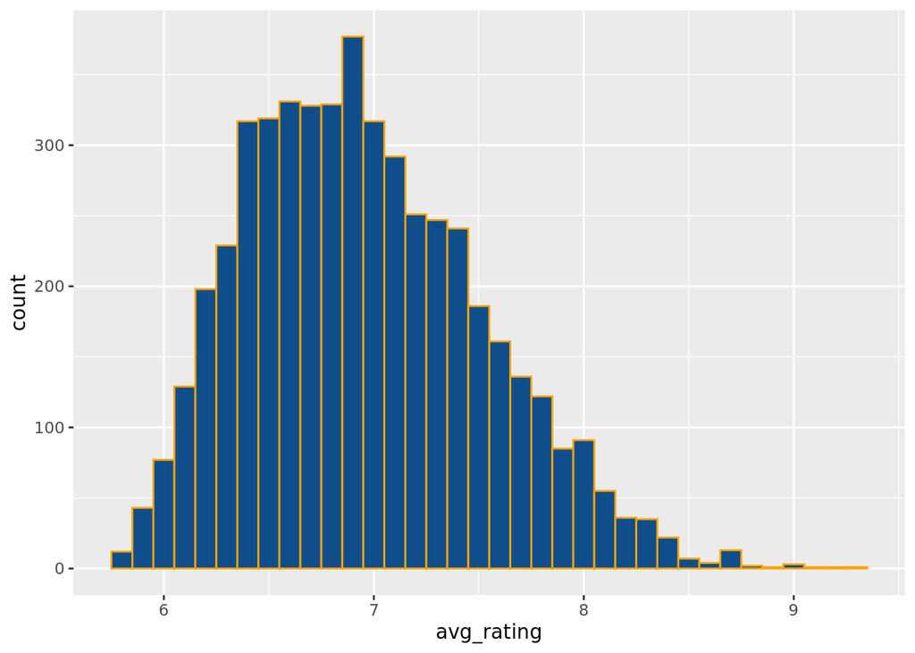

```r
#Visualize average ratings
ggplot(data, aes(x = avg_rating))+
  geom_histogram(binwidth = 0.1, fill = "dodgerblue4", color = "orange")
```

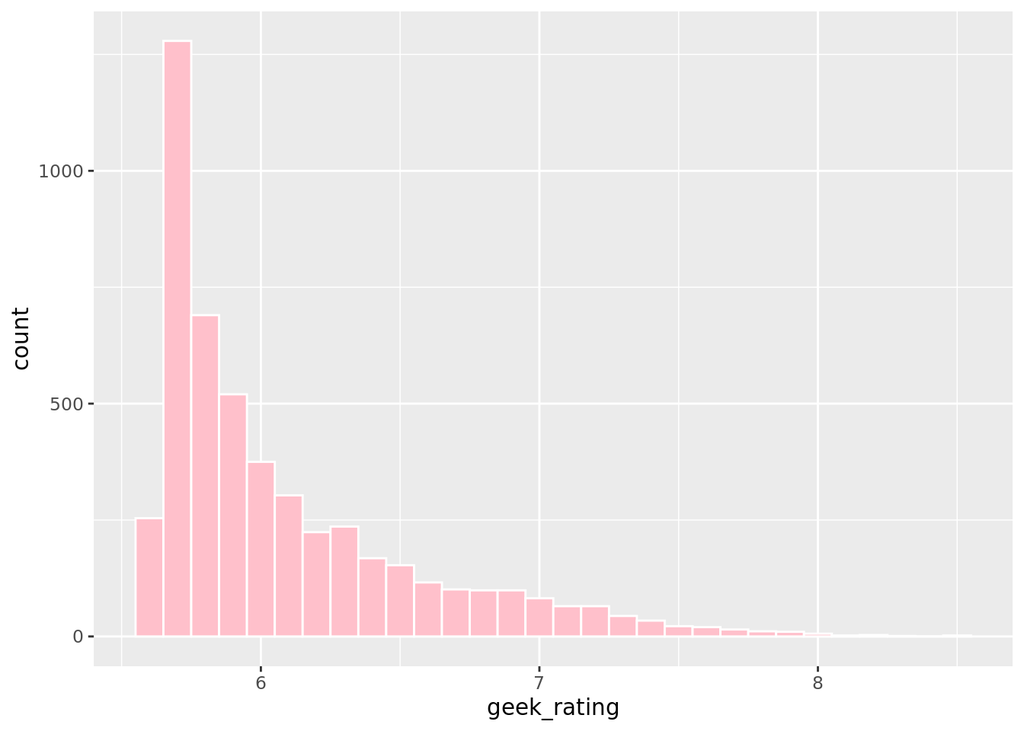

```r
#Visualize geek ratings
ggplot(data, aes(x = geek_rating))+
  geom_histogram(binwidth = 0.1, fill = "pink", color = "white")
```

```r
#Provide summary statistics for avg_ratings
summarized_avg_ratings <- data %>%
  summarize(avg_rating_mean = mean(avg_rating), avg_rating_median = median(avg_rating))
summarized_avg_ratings
```

```
## # A tibble: 1 x 2
##   avg_rating_mean avg_rating_median
##             <dbl>             <dbl>
## 1            6.96              6.90
```

```r
#Provide summary statistics for geek_ratings
summarized_geek_ratings <- data %>%
  summarize(geek_rating_mean = mean(geek_rating), geek_rating_median = median(geek_rating))
summarized_geek_ratings
```

```
## # A tibble: 1 x 2
##   geek_rating_mean geek_rating_median
##              <dbl>              <dbl>
## 1             6.08               5.90
```

#### Q1 Response:

To visualize the distribution of both average ratings and geek ratings, I’ve created two histograms. I selected histograms to represent the distribution because each bin in the histogram shows the count of a particular rating. As the number of a particular rating increase, so does the count, which forms the shape of the distribution of the ratings.

To find the mean and median, I created two variables (summarized_avg_ratings and summarized_geek_ratings) and utilized the summarize function to perform the calculations.

Examining the tibble above, we can see that for avg_ratings, the mean is 6.96 and median is 6.9. There are no excessive outliers pulling the mean in a particular direction and the median value is only .06 rating away, so both are acceptable for measuring the center of the distribution.

For geek_ratings, the situation is slightly different. The mean geek rating is 6.08 and the median is 5.9. The difference of .18 rating between the median and mean suggests that there may be outliers towards the higher end of the distribution that pull the value of the mean upwards. Looking at the visualization for the geek_ratings further confirms this theory. As a result, the median is likely a better measure of the center as many of the values cluster below 6.

### Question 2 (5 points)

The original data set includes some columns that will not be useful for our analysis. Create a new dataframe that **does not** include the game id, the bgg url, and the image url columns. Use the cleaned data frame to create another data frame containing the top 500 ranked games and assign it to a separate variable. Note: This can be accomplshed in one step using pipes!

```r
#Create a new data frame and remove the game_id, bgg_url, and image_url variables
games_cleaned <- data %>%
  select(-game_id, -bgg_url, -image_url) %>%
  filter(rank <= 500)
```

### Question 3 (20 points)

Within the top 500 games there is a large variety of games with different player counts. How do the ratings of games appear to differ between games with different maximum player counts? Give both a numeric summary and a visualization to demonstrate the average rating, spread, and number of games for each maximum player count. What set of maximum player counts appear to have higher ratings?

(For the rest of the assignment, use avg_rating for any prompts involving game rating)

```r
#Summarize each of the games by maximum players
max_player_ratings <- games_cleaned %>%
  group_by(max_players) %>%
    summarize(mean_rating = mean(avg_rating),standard_deviation = sd(avg_rating), num_games = n())
max_player_ratings
```

```
## # A tibble: 12 x 4
##    max_players mean_rating standard_deviation num_games
##          <dbl>       <dbl>              <dbl>     <int>
##  1           1        7.23            NA              1
##  2           2        7.65             0.318         70
##  3           3        7.91             0.264          5
##  4           4        7.64             0.377        207
##  5           5        7.53             0.302        120
##  6           6        7.62             0.440         53
##  7           7        7.39             0.355         14
##  8           8        7.42             0.334         20
##  9          10        7.41             0.252          5
## 10          12        7.53             0.0311         2
## 11          18        7.56             0.312          2
## 12          20        7.78            NA              1
```

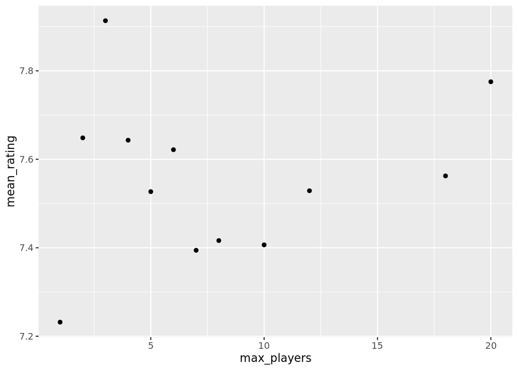

```r
#Scatterplot of average of average ratings by number of max players
ggplot(max_player_ratings, aes(x = max_players, y = mean_rating))+
  geom_point()
```

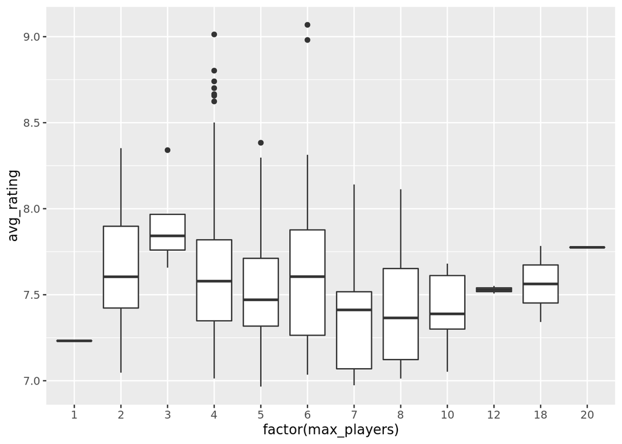

```r
#Spread of average ratings
ggplot(games_cleaned,aes(x= factor(max_players), y = avg_rating))+
  geom_boxplot()
```

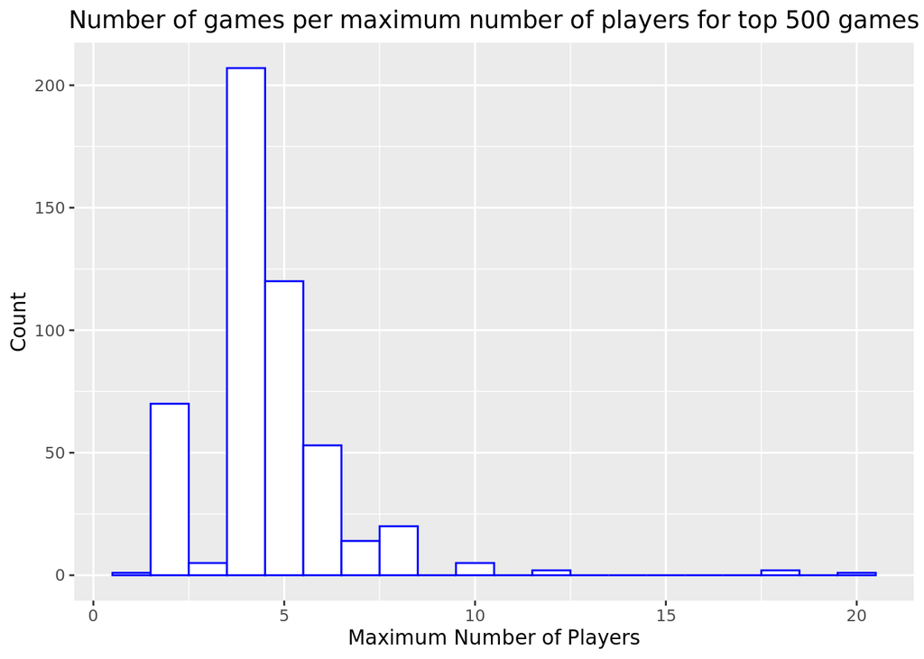

```r
#Number of games with X maximum players
ggplot(games_cleaned,aes(x = max_players))+
  geom_histogram(binwidth = 1, color = "blue", fill = "white")+
  labs(title = "Number of games per maximum number of players for top 500 games", y = "Count", x = "Maximum Number of Players")+
  theme(plot.title = element_text(hjust=0.5))
```

#### Q3 Response:

How do the ratings of games appear to differ between games with different maximum player counts?

To observe the differences in rating among games with different player counts I created a tibble grouping games by their maximum player count and then summarized the mean average rating, standard deviation of average rating, and number of games with that particular number of maximum players. Additionally, I created a boxplot to represent the 5 point summary factored by maximum number of players.

What set of maximum player counts appear to have higher ratings?

Returning to the tibble, we can see that three player games have the highest mean rating. I created a visualization of mean ratings using a scatterplot to make this clearer. However, I do not have full confidence in claiming that three player games achieve higher ratings in general. The sample size for number of games is low at a total of 5 games. It is possible that those 5 games in particular are awesome games and as a result rate higher than other games. In fact, I would argue that 2 and 4 player games maximum player count is more associated to their higher rating than 3 person games.

Looking again at the histogram, we see that there are certainly more 2 and 4 player games, which means our sample is more likely to be representative of the population of all 2 and 4 player games. Looking at the ratings in the tibble, 2 and 4 player games come in at 7.65 and 7.64 respectively. That clinches the 3rd and 4th place for highest ratings among the dataset. I believe these games are more highly rated because of their ease in creating groups. 2 player games are easy as you only need one other player and 4 is convenient for a nuclear family unit. As a result, these games earn higher ratings because group formation is simple and group dynamics in even groups are more harmonious. 3 and 20 player games (rank 1 and 2 in the average rating), have far fewer games and are difficult to form. As a result, there are fewer games produced and their average ratings are pulled higher than is actually representative of the true rating of the game.

### Question 4 (15 points)

Which game is owned by the most BGG users and what rank is it? How does the player count and play time for this game compare to other games in the top 500? Discuss your findings below the code block showing your code that found the values.

```r
#Most owned game
 most_owned_game <- games_cleaned %>%
  filter(owned == max(owned))
most_owned_game
```

```
## # A tibble: 1 x 17
##    rank names min_players max_players avg_time min_time max_time  year
##   <dbl> <chr>       <dbl>       <dbl>    <dbl>    <dbl>    <dbl> <dbl>
## 1   272 Catan           3           4      120       60      120  1995
## # … with 9 more variables: avg_rating <dbl>, geek_rating <dbl>,
## #   num_votes <dbl>, age <dbl>, mechanic <chr>, owned <dbl>,
## #   category <chr>, designer <chr>, weight <dbl>
```

```r
#Summary of top 500 games
top_500_games_summarized <- games_cleaned %>%
  summarize(median_max_players = median(max_players), median_average_time = median(avg_time), mean_avg_time = mean(avg_time), standard_deviation_of_time = sd(avg_time))
top_500_games_summarized
```

```
## # A tibble: 1 x 4
##   median_max_players median_average_t… mean_avg_time standard_deviation_of…
##                <dbl>             <dbl>         <dbl>                  <dbl>
## 1                  4                90          102.                   84.7
```

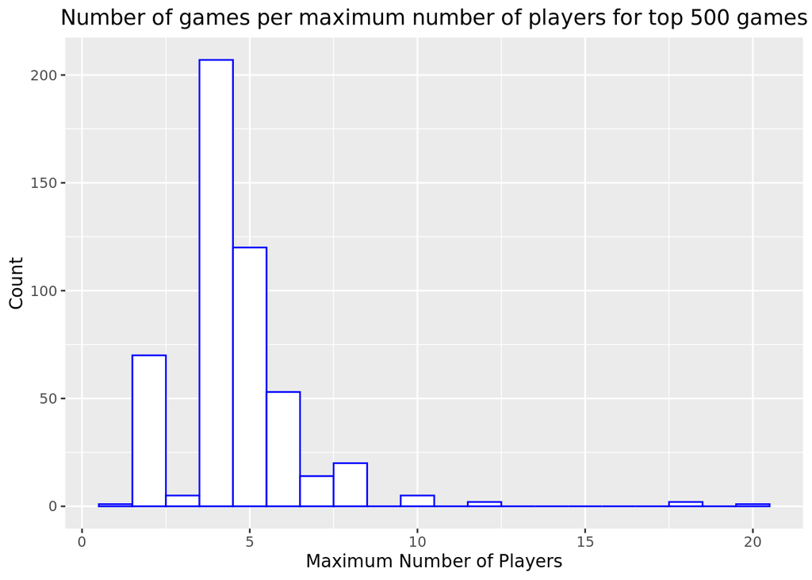

```r
#Histogram showing the distribution of maximum players for all of the games in the top 500
ggplot(games_cleaned,aes(x = max_players))+
  geom_histogram(binwidth = 1, color = "blue", fill = "white")+
  labs(title = "Number of games per maximum number of players for top 500 games", y = "Count", x = "Maximum Number of Players")+
  theme(plot.title = element_text(hjust=0.5))
```

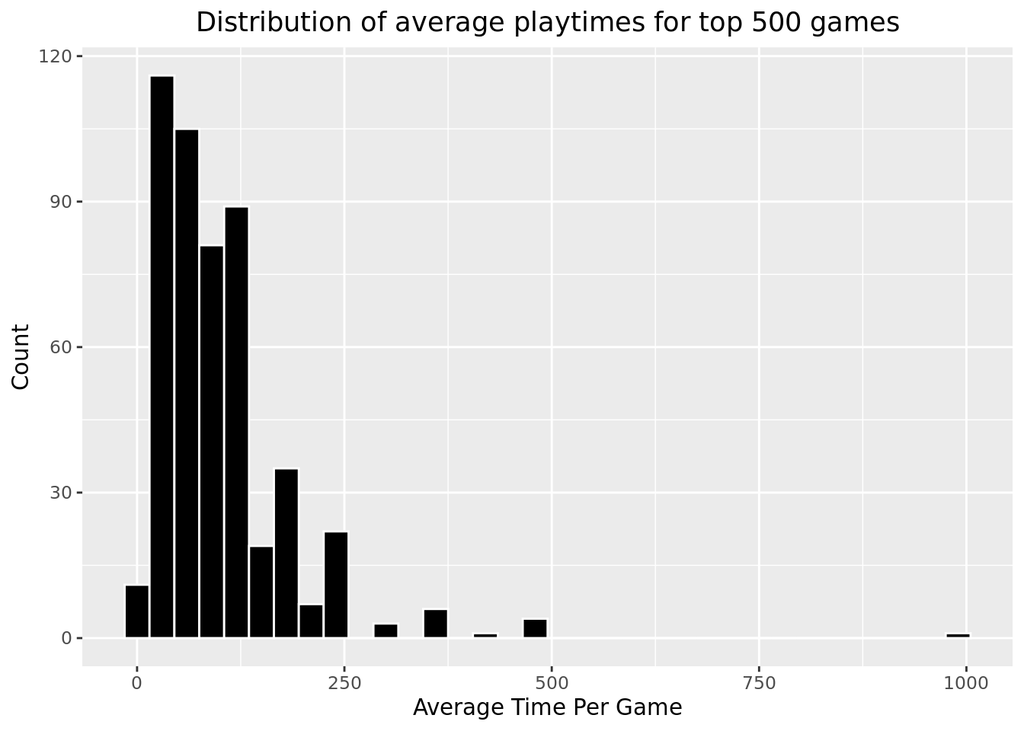

```r
#Histogram showing the distribution of avg_playtimes for all of the games in the top 500
ggplot(games_cleaned, aes(x = avg_time))+
  geom_histogram(binwidth = 30,fill = "black", color ="white")+
  labs(title = "Distribution of average playtimes for top 500 games", y = "Count", x = "Average Time Per Game")+
  theme(plot.title = element_text(hjust=0.5))
```

#### Q4 Response:

Which game is owned by the most BGG users and what rank is it?

To find the most owned game in the top 500 I created a new variable using the games_cleaned dataset. I filtered the dataset to only show the max() of the owned variable. The most owned game by BGG users is Catan which has a corresponding rank of 272.

How does the player count and play time for this game compare to other games in the top 500?

To compare Catan’s player count and play time to other games in the top 500, I created a variable with summary statistics of games in the top 500 using the summarize function. The three summary statistics I created are the median maximum number of players, median average time, and the standard deviation of average time.

I selected the median for max number of players because max number of players is a discrete variable and thus the median will return an integer. I selected the median average time to represent the center of the distribution of average time spent playing a particular game in the top 500. I selected the median because there is one game (The Seventh Continent) with an average time of 1000, which skews the data if the mean is used.However, I included the mean of the average time for comparative purposes as well.Lastly, I calculated the standard deviation to see where Catan falls within the distribution of average time.

Compared to other games in the Top 500, Catan has the same maximum number of players as the median of the top 500 at 4. Utilizing the histogram I created in problem 3, we can confirm this visually as well.

Catan’s average time is longer than the median average of the top 500 games by 30 minutes at 120 minutes long. I visualized this using a histogram showing the distribution of average play time for all games in the top 500. Lastly, Catan’s average playtime falls within one standard deviation of the mean.

By these measures, Catan looks like a typical game for the top 500. Further analysis is necessary to understand why Catan is not ranked higher despite being the most owned game. One possible explanation for Catan’s high ownership is the age of the game in conjunction with the spike in popularity Catan received in recent years. Catan is from 1995, meaning it’s had some time for sales to occur year after year. Those accumulated sales, in addition to the new sales driven by the resurgence in popularity may combine to show the ownership we see here.

### Question 5 (15 points)

Does there appear to be a relationship between game weight (https://boardgamegeek.com/wiki/age/Weight) and the number of players? Write your thoughts below the code block containing numerical analysis or a visualization. (You may find a boxplot helpful here)

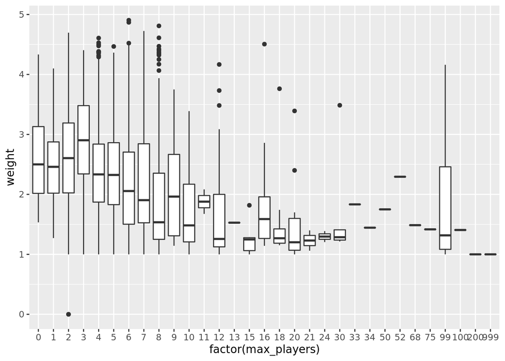

```r
ggplot(data, aes(x = factor(max_players), y = weight))+
  geom_boxplot()
```

#### Q5 Response:

To observe the relationship between weight and maximum number of players, I created a boxplot using the data dataset (and not just the top 500) which factors upon the maximum number of players.

Assume weight is a scale starting at 1 and ending at 5 with 1 being the “lightest” and 5 being the “heaviest.” (It is not explicitly stated at https://boardgamegeek.com/wiki/page/Weight that higher numbers means a heavier weight).

One explanation for weight decreasing as maximum players increases is that games with more people need to be simpler to play. Games that are complex require much explanation and getting a large number of people on the same page is no easy task. Also, games with complex rulesets likely take longer to play. As player numbers and complexity goes up, the time to complete a game goes up as well. As a result, game makers design games for a large number players with easier rulesets for the sake of time and ease of play.

### Question 6 (15 points)

Create a plot showing the number of board games released by year. What trends do you notice?

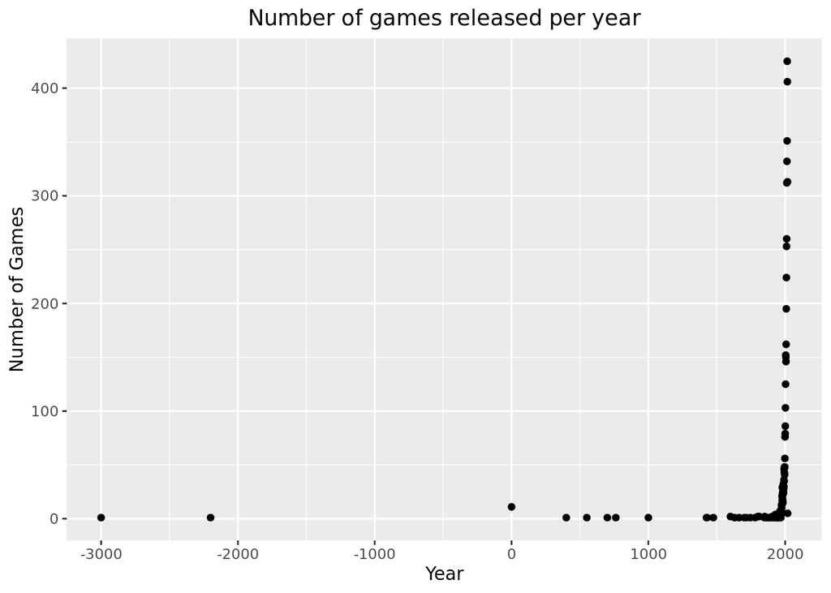

```r
#Unfiltered
games_by_year <- data %>%
  group_by(year) %>%
  summarize(games_per_year = n())


ggplot(games_by_year, aes(x = year, y = games_per_year)) +
  geom_point()+
  labs(title = "Number of games released per year", y = "Number of Games", x = "Year")+
  theme(plot.title = element_text(hjust=0.5))
```

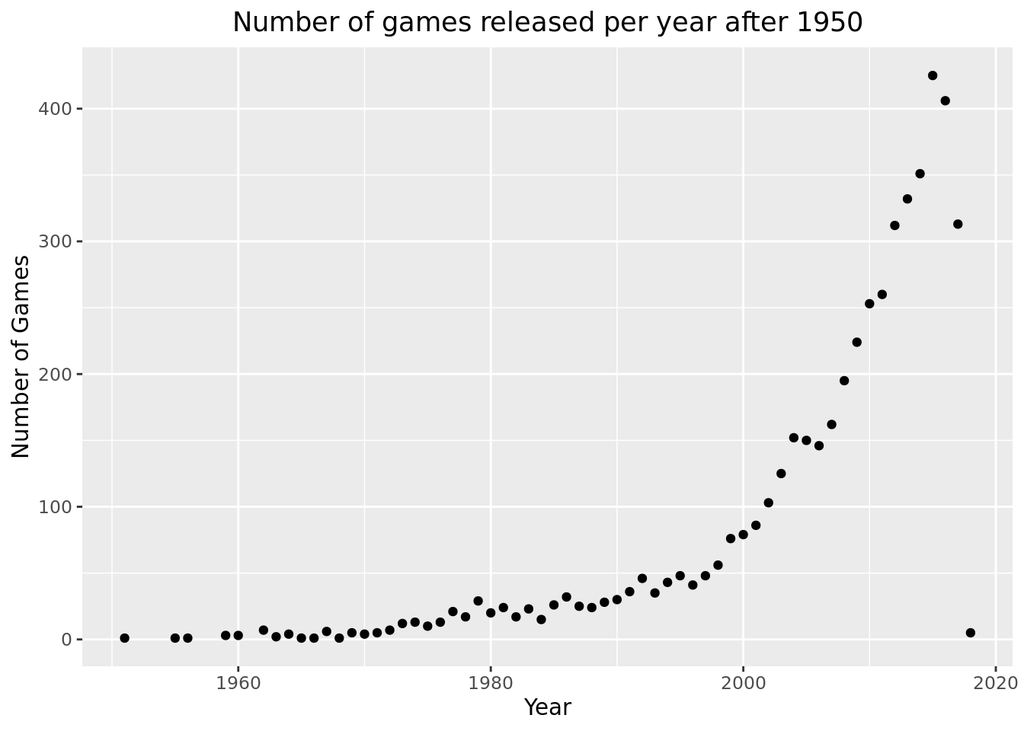

```r
#Filtered for after year 1950
games_by_year_after_1950 <- games_by_year%>%
  filter(year >= 1950)

ggplot(games_by_year_after_1950, aes(x = year, y = games_per_year)) +
  geom_point()+
  labs(title = "Number of games released per year after 1950", y = "Number of Games", x = "Year")+
  theme(plot.title = element_text(hjust=0.5))
```

#### Q6 Response:

To view the number of board games released per year, I created two new variables. In both, I used the full data dataset. I grouped by year and summarized, counting the number of games released each year. To visualize this, I created two scatterplots. In the first scatterplot all years and number of games released per year are included. This visualization is not very helpful, as there are a few outlier ancient games which make it difficult to see the overall trend.

To better view the trend, I filtered the games to only include games released after 1950. Beginning the plot at 1950, we can see a steady increase in the number of games released per year. In the 1990s the pace quickens and after 2000, the number of games released per year begins to dramatically rise. The overall trend of games being released by year is upward with a slight decline over the past few years.

There is one datapoint for year 2018 in which the value is 5. This seems very out of line with the previous trends. This data is likely a result of the release of the dataset. If the dataset is released early in the year, there will be fewer observations for that year, which explains why 2018 does not match the trend.

## Question 7 (10 points)

Which games have more votes than owners? Create a new column in your top 500 dataframe labeled vote_own_ratio expressing the ratio of votes to owners.

```r
#Create new column for vote_own_ratio
games_cleaned <- games_cleaned %>%
  mutate(vote_own_ratio = num_votes/owned)


#Tibble showing games with more votes than owners
vote_ratio <- games_cleaned %>%
  select(rank,names,num_votes,owned,vote_own_ratio) %>%
  filter(vote_own_ratio >= 1)
vote_ratio
```

```
## # A tibble: 30 x 5
##     rank names                               num_votes owned vote_own_ratio
##    <dbl> <chr>                                   <dbl> <dbl>          <dbl>
##  1    49 El Grande                               19489 18802           1.04
##  2    70 Crokinole                                8399  6170           1.36
##  3    98 Goa                                     10001  9913           1.01
##  4   102 Hansa Teutonica                          9126  9002           1.01
##  5   105 Age of Steam                             6980  6517           1.07
##  6   111 Viticulture                              7001  6927           1.01
##  7   131 Age of Empires III: The Age of Dis…      9129  7761           1.18
##  8   133 Ra                                      16200 15337           1.06
##  9   135 Imperial                                 7437  6360           1.17
## 10   156 Navegador                                6576  6395           1.03
## # … with 20 more rows
```

```r
#Test whether this is a problem for the larger dataset
test_data <- data %>%
  mutate(vote_own_ratio = num_votes/owned) %>%
  filter(vote_own_ratio >= 1)
```

To find the vote to owner ratio, I created a new variable in the games_cleaned data frame using mutate and dividing num_votes by owned. To find which games had more votes than owners, I created a new variable and filtered all of the games in games_cleaned that had a vote to owned ratio of more than 1. If a game had a vote to owned ratio greater than one, it means that there are more votes than number of games owned.

Within the top 500, 6% or 30 of the games had a vote to owner ratio of more than 1. To see whether this was a problem in the larger dataset, I did the same series of operations as before and found that 151 of the 4999 observations had a vote to owned ratio of more than 1. Of this 151, 20% (30 games) are in the top 500. It is unclear how this ratio affects ranking, but there is a possibility that the increased number of votes coupled with a lower ownership number for the observation increases the chances of the game being placed in the top 500.